# Modeling

Alexia Wells

2025-04-19

# Read Me

If you would like to run the contents of this document on your own, please remove eval=FALSE in the modeling code chunks. They are set to false because these models take a long time computationally. To get the same results, please run the data and models on a server. Thank you.

# Introduction

## Project Goal and Purpose of the Notebook

The purpose of this notebook is to develop a predictive analytics model that estimates a client’s annual sales volume, helping to identify those likely to exceed the optimal growth threshold of 400 gallons. Moreover, the notebook will start with data preparation and go into model building, evaluation, and results.

## Business Problem

Swire Coca-Cola is a leading tech company that puts clients at the center of their work. As a bottler and distributor throughout 13 Western states, operational efficiency is a necessity to remain successful and create long-term relationships with clientele. Swire Coca-Cola must avoid prematurely moving high-growth potential customers to white truck delivery (Alternate Route to Market) as this could severely impact revenue growth. The purpose of this project is to reasonably maximize sales by predicting which clients have the potential to reach the high-performing SCCU optimal threshold of 400 gallons annually.

## Analytical Problem

Several models will be created in attempt to address Swire Coca-Cola’s business needs. A balanced approach will be used to inform client growth by taking into account historical sales data and other customer characteristics.

# Data Preparation

I removed several of those columns to avoid issues of multicollinearity since it was redundant information. Other columns like full address, zip code, and primary group number were removed out of simplifying the modeling process.

Considering that I had to remove several columns for multicollinearity, I wanted to avoid data loss as much as I could. For that reason, I feature engineered 3 columns: month, load difference, and shipment difference. Month was extracted from transaction date while loaded difference is a calculation representing the amount of ordered - loaded gallons and cases. This was similar for shipment difference, loaded - delivered. I also factored several columns.

```r
# Load the libraries
library(vroom) # for quickly reading in/writing out
library(tidyverse)
library(tidymodels)
library(lubridate) # to seperate date
library(DataExplorer)
library(caret)
library(car) # helps check for multicollinarity
library(MASS) # for boxcox
```

```r
# Read in the data, train and test should be included here
train <- vroom("train_set.csv")
test <- vroom("test_set.csv")
```

## Checking the Data and Feature Engineering

Removed some columns due to redundancy (I.E Transaction_Date, All ordered, loaded, delivered gallons and casese). I actually ran into memory issues while running linear models - “Error: vector memory limit of 16.0 Gb reached, see mem.maxVSize().”

Feature engineered month column and two columns representing disparity between ordered/loaded, and loaded/delivered

```r
# Checking Column Names
colnames(train)
colnames(test)

# Check for duplicated data, there is none
anyDuplicated(train)

# Will need to factor the train and test set
str(train)
```

```r
# LOADED_DIFFERENCE = Ordered-loaded
# SHIPMENT_DIFFERENCE = loaded-delivered
train_set <- train |>
   mutate(across(c(CUSTOMER_NUMBER, ORDER_TYPE, PRIMARY_GROUP_NUMBER,
                  FREQUENT_ORDER_TYPE, COLD_DRINK_CHANNEL,
                  TRADE_CHANNEL, SUB_TRADE_CHANNEL, LOCAL_MARKET_PARTNER,
                  CO2_CUSTOMER, ZIP_CODE, ORDER_GROUPING), as.factor)) |>
  mutate(across(c(TRANSACTION_DATE, FIRST_DELIVERY_DATE, ON_BOARDING_DATE),
                ~ as.Date(., format = "%m/%d/%Y"))) |>
  mutate(MONTH = month(TRANSACTION_DATE), LOADED_DIFFERENCE =
           TOTAL_UNITS_ORDERED - TOTAL_UNITS_LOADED, SHIPMENT_DIFFERENCE =
           TOTAL_UNITS_LOADED - TOTAL_UNITS_DELIVERED) |>
  mutate(ORDER_GROUPING = ifelse(ORDER_GROUPING == "Customers Ordering Less than 400", 0, 1)) |> # if it is that phrase, replace with 0, if over 400 we want to say 1
  mutate(across(c(WEEK, MONTH), as.factor)) |>
  mutate(TOTAL_UNITS_ORDERED= ifelse(
    TOTAL_UNITS_ORDERED == min(TOTAL_UNITS_ORDERED),
    TOTAL_UNITS_ORDERED + abs(min(TOTAL_UNITS_ORDERED)) + 0.01,
    TOTAL_UNITS_ORDERED)) |>
  dplyr::select(-c(ORDERED_CASES,LOADED_CASES,DELIVERED_CASES,ORDERED_GALLONS,
                   LOADED_GALLONS, DELIVERED_GALLONS, TRANSACTION_DATE,
                   full.address, ZIP_CODE, PRIMARY_GROUP_NUMBER))

# Now do the same to test
test_set <- test |>
   mutate(across(c(CUSTOMER_NUMBER, ORDER_TYPE, PRIMARY_GROUP_NUMBER,
                  FREQUENT_ORDER_TYPE, COLD_DRINK_CHANNEL,
                  TRADE_CHANNEL, SUB_TRADE_CHANNEL, LOCAL_MARKET_PARTNER,
                  CO2_CUSTOMER, ZIP_CODE, ORDER_GROUPING), as.factor)) |>
  mutate(across(c(TRANSACTION_DATE, FIRST_DELIVERY_DATE, ON_BOARDING_DATE),
                ~ as.Date(., format = "%m/%d/%Y"))) |>
  mutate(MONTH = month(TRANSACTION_DATE), LOADED_DIFFERENCE =
           TOTAL_UNITS_ORDERED - TOTAL_UNITS_LOADED, SHIPMENT_DIFFERENCE =
           TOTAL_UNITS_LOADED - TOTAL_UNITS_DELIVERED) |>
  mutate(ORDER_GROUPING = ifelse(ORDER_GROUPING == "Customers Ordering Less than 400", 0, 1)) |> # if it is that phrase, replace with 0, if over 400 we want to say 1
  mutate(across(c(WEEK, MONTH), as.factor)) |>
  mutate(TOTAL_UNITS_ORDERED= ifelse(
    TOTAL_UNITS_ORDERED == min(TOTAL_UNITS_ORDERED),
    TOTAL_UNITS_ORDERED + abs(min(TOTAL_UNITS_ORDERED)) + 0.01,
    TOTAL_UNITS_ORDERED)) |>
  dplyr::select(-c(ORDERED_CASES,LOADED_CASES,DELIVERED_CASES,ORDERED_GALLONS,
                   LOADED_GALLONS, DELIVERED_GALLONS, TRANSACTION_DATE,
                   full.address, ZIP_CODE, PRIMARY_GROUP_NUMBER))

# There is near zero variance for shipment difference, so will need to consider whether it should be kept
nearZeroVar(train_set, saveMetrics = TRUE)
```

```
##                              freqRatio percentUnique zeroVar   nzv
## WEEK                          1.014752  0.0071295480   FALSE FALSE
## YEAR                          1.014815  0.0002742134   FALSE FALSE
## CUSTOMER_NUMBER               1.228125  2.9099524377   FALSE FALSE
## ORDER_TYPE                    1.119873  0.0009597468   FALSE FALSE
## FREQUENT_ORDER_TYPE           3.937187  0.0008226402   FALSE FALSE
## FIRST_DELIVERY_DATE           1.037126  0.3195956998   FALSE FALSE
## ON_BOARDING_DATE              1.279048  0.7927508950   FALSE FALSE
## COLD_DRINK_CHANNEL            3.036313  0.0012339602   FALSE FALSE
## TRADE_CHANNEL                 1.502847  0.0035647740   FALSE FALSE
## SUB_TRADE_CHANNEL             1.872574  0.0065811212   FALSE FALSE
## LOCAL_MARKET_PARTNER          4.768100  0.0002742134   FALSE FALSE
## CO2_CUSTOMER                  1.590430  0.0002742134   FALSE FALSE
## TOTAL_UNITS_ORDERED           1.020676  2.0228721384   FALSE FALSE
## TOTAL_UNITS_LOADED            1.040565  1.9112672909   FALSE FALSE
## TOTAL_UNITS_DELIVERED         1.035681  2.1834240751   FALSE FALSE
## ORDER_GROUPING                1.297773  0.0002742134   FALSE FALSE
## CUSTOMER_GROUP_NUMBER_ROLLUP  3.201493  1.8577956809   FALSE FALSE
## Total_Delivery_Cost           4.634103  2.6931867571   FALSE FALSE
## MONTH                         1.091506  0.0016452803   FALSE FALSE
## LOADED_DIFFERENCE            12.598464  0.4085779431   FALSE FALSE
## SHIPMENT_DIFFERENCE          28.998827  0.2954649219   FALSE  TRUE
```

```r
nearZeroVar(test_set, saveMetrics = TRUE)
```

```
##                              freqRatio percentUnique zeroVar   nzv
## WEEK                          1.010082  0.0164462760   FALSE FALSE
## YEAR                          1.011995  0.0006325491   FALSE FALSE
## CUSTOMER_NUMBER               1.009554  2.8774657554   FALSE FALSE
## ORDER_TYPE                    1.079598  0.0022139218   FALSE FALSE
## FREQUENT_ORDER_TYPE           4.174676  0.0018976472   FALSE FALSE
## FIRST_DELIVERY_DATE           1.010263  0.6581673156   FALSE FALSE
## ON_BOARDING_DATE              1.071346  1.2660469794   FALSE FALSE
## COLD_DRINK_CHANNEL            3.064387  0.0028464709   FALSE FALSE
## TRADE_CHANNEL                 1.501418  0.0079068635   FALSE FALSE
## SUB_TRADE_CHANNEL             2.030238  0.0139160797   FALSE FALSE
## LOCAL_MARKET_PARTNER          4.414615  0.0006325491   FALSE FALSE
## CO2_CUSTOMER                  1.511805  0.0006325491   FALSE FALSE
## TOTAL_UNITS_ORDERED           1.002148  2.5033129758   FALSE FALSE
## TOTAL_UNITS_LOADED            1.032266  2.3992586525   FALSE FALSE
## TOTAL_UNITS_DELIVERED         1.032654  2.7142680933   FALSE FALSE
## ORDER_GROUPING                1.333956  0.0006325491   FALSE FALSE
## CUSTOMER_GROUP_NUMBER_ROLLUP  2.659827  1.9419256692   FALSE FALSE
## Total_Delivery_Cost           2.579747  3.1447177408   FALSE FALSE
## MONTH                         1.089678  0.0037952945   FALSE FALSE
## LOADED_DIFFERENCE            12.599481  0.4984486734   FALSE FALSE
## SHIPMENT_DIFFERENCE          29.403838  0.3924967028   FALSE  TRUE
```

```r
# Check that both datasets look correct
str(train_set)
str(test_set)
```

## Visualizations and Tables

### Bar Plots

```
## 4 columns ignored with more than 50 categories.
## WEEK: 52 categories
## CUSTOMER_NUMBER: 21224 categories
## FIRST_DELIVERY_DATE: 2331 categories
## ON_BOARDING_DATE: 5782 categories
```

[figure not shown]

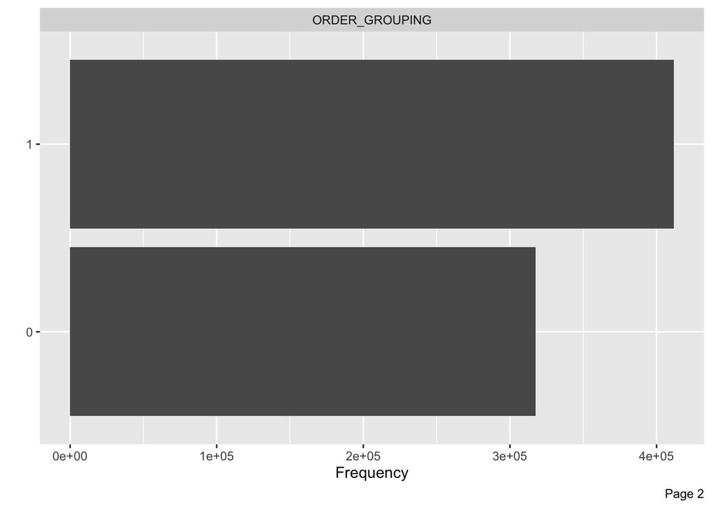

```r
plot_bar(train_set)
```

### Distribution of Units Ordered, Loaded, and Delivered

```r
summary(train_set[13:15])
```

```
##  TOTAL_UNITS_ORDERED TOTAL_UNITS_LOADED TOTAL_UNITS_DELIVERED
##  Min.   :   0.01     Min.   :   0.00    Min.   :-1894.00
##  1st Qu.:   9.00     1st Qu.:   8.00    1st Qu.:    7.50
##  Median :  15.50     Median :  15.00    Median :   15.00
##  Mean   :  36.54     Mean   :  35.35    Mean   :   34.19
##  3rd Qu.:  30.00     3rd Qu.:  29.00    3rd Qu.:   28.00
##  Max.   :8479.89     Max.   :8171.56    Max.   : 8069.48
```